# Reproducible Research: Peer Assessment 1

## Summary

Storms and other severe weather events can cause both public health and economic problems for communities and municipalities. Many severe events can result in fatalities, injuries, and property damage, and preventing such outcomes to the extent possible is a key concern.

This project involves exploring the U.S. National Oceanic and Atmospheric Administration’s (NOAA) storm database. This database tracks characteristics of major storms and weather events in the United States, including when and where they occur, as well as estimates of any fatalities, injuries, and property damage.

Based on the data, I conclude that tornados pose the biggest threat to human life, they cause overwhelming majority of fatalities and injuries.  
I also conclude that high winds, tornados, and floods are responsible for majority of property and crop damages.

## Loading and preprocessing the data

```r
# download, unzip, and read the csv

# http://stackoverflow.com/a/20003380
setInternet2(TRUE)

data_file <- 'https://d396qusza40orc.cloudfront.net/repdata%2Fdata%2FStormData.csv.bz2'
temp <- tempfile()
download.file(data_file, temp)
data <- read.csv(bzfile(temp))
unlink(temp)
```

EVTYPE column is problematic, there are spelling variations, for example “THUNDERSTORM WIND” vs “THUNDERSTORM WINDS”

```r
unique(data$EVTYPE)
```

```
##   [1] TORNADO                        TSTM WIND
##   [3] HAIL                           FREEZING RAIN
##   [5] SNOW                           ICE STORM/FLASH FLOOD
##   [7] SNOW/ICE                       WINTER STORM
##   [9] HURRICANE OPAL/HIGH WINDS      THUNDERSTORM WINDS
##  [11] RECORD COLD                    HURRICANE ERIN
##  [13] HURRICANE OPAL                 HEAVY RAIN
##  [15] LIGHTNING                      THUNDERSTORM WIND
##  [17] DENSE FOG                      RIP CURRENT
##  [19] THUNDERSTORM WINS              FLASH FLOOD
##  [21] FLASH FLOODING                 HIGH WINDS
##  [23] FUNNEL CLOUD                   TORNADO F0
##  [25] THUNDERSTORM WINDS LIGHTNING   THUNDERSTORM WINDS/HAIL
##  [27] HEAT                           WIND
##  [29] LIGHTING                       HEAVY RAINS
```

[output cut: 479 more lines]

```r
# alter the factor variable to char so we can add more values
data$EVTYPE <- as.character(data$EVTYPE)

# add a column indicating if this event is high wind related
data$EVTYPE[grepl("THUNDERSTORM|TSTM|WIND|WND", data$EVTYPE, ignore.case=TRUE)] <- 'wind'

# add a column indicating if this event is flooding related
data$EVTYPE[grepl("flood|fld", data$EVTYPE, ignore.case=TRUE)] <- 'flood'

# set it back as a factor
data$EVTYPE <- as.factor(data$EVTYPE)
```

## Results

### First, explore most dangerous events, defined as combination of fatalities and injuries.

```r
# create a column representing total population damage (fatalities and injuries)
data$popDamage <- data$FATALITIES + data$INJURIES

# sum up the population damage for each event type
totalPopDamage <- aggregate(data[, 'popDamage'], by=list(data$EVTYPE), FUN = sum)
colnames(totalPopDamage) <- c('event', 'damage')

# show top 5 most dangerous events
sorted <- totalPopDamage[with(totalPopDamage, order(-damage)), ]
top <- head(sorted, 5)
top
```

```
##              event damage
## 543        TORNADO  96979
## 621           wind  12990
## 115          flood  10236
## 97  EXCESSIVE HEAT   8428
## 309      LIGHTNING   6046
```

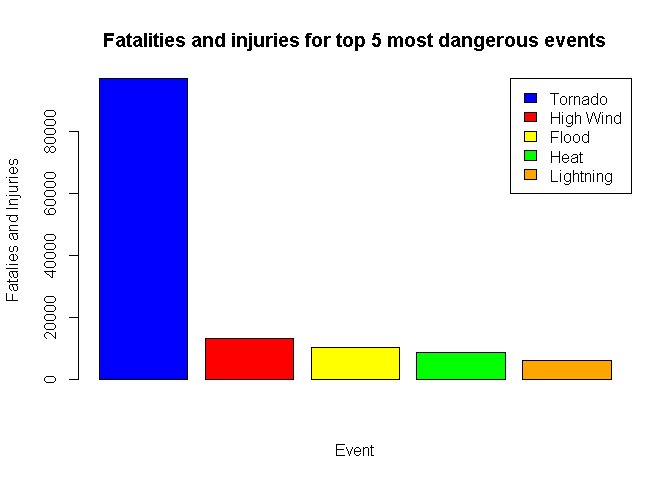

```r
# visualization of scale difference between top 5 most dangerous events
barplot(
    top$damage,
    main = 'Fatalities and injuries for top 5 most dangerous events',
    xlab = 'Event',
    ylab = 'Fatalies and Injuries',
    legend.text = c("Tornado", "High Wind", "Flood", "Heat", "Lightning"),
    args.legend = list(x = "topright"),
    col = c('blue', 'red', 'yellow', 'green', 'orange')
  )
```

### Now lets explore the economic impact

```r
# create a column representing total economic damage (propery damage and crop damage)
data$econDamage <- data$PROPDMG + data$CROPDMG

# sum up the population damage for each event type
totalEconDamage <- aggregate(data[, 'econDamage'], by=list(data$EVTYPE), FUN = sum)
colnames(totalEconDamage) <- c('event', 'damage')

# show top 5 most dangerous events
sorted <- totalEconDamage[with(totalEconDamage, order(-damage)), ]
top <- head(sorted, 5)
top
```

```
##         event    damage
## 621      wind 3361094.5
## 543   TORNADO 3312276.7
## 115     flood 2828789.3
## 157      HAIL 1268289.7
## 309 LIGHTNING  606932.4
```

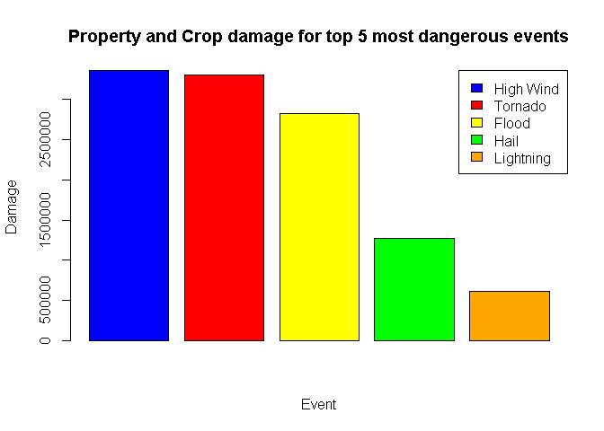

```r
# visualization of scale difference between top 5 most dangerous events
barplot(
  top$damage,
  main = 'Property and Crop damage for top 5 most dangerous events',
  xlab = 'Event',
  ylab = 'Damage',
  legend.text = c("High Wind", "Tornado", "Flood", "Hail", "Lightning"),
  args.legend = list(x = "topright"),
  col = c('blue', 'red', 'yellow', 'green', 'orange')
)
```

## Conclusion

Tornados pose the biggest threat to human life, they cause overwhelming majority of fatalities and injuries.  
High winds, tornados, and floods are responsible for majority of property and crop damages.